# pp4 slides

# Feature Selection

```python
# Alle Spalten anzeigen
df.columns
```

```
Index(['distance_from_home', 'distance_from_last_transaction',
       'ratio_to_median_purchase_price', 'repeat_retailer', 'used_pin_number',
       'online_order', 'fraud', 'var'],
      dtype='object')
```

### Target Variable

In unserem Projekt geht es darum, Transaktionsfälle zu klassifizieren, ob es sich dabei um Fraud handeln kann. In diesem Datensatz ist also die Fraud-Spalte die Target Variable. Es gibt insgesamt 7 weitere Spalten, die mögliche Features für unseren Klassifikationsfall darstellen können.

Die Features mit einer gewissen Korrelation und Kausalität beinhalten keine Informationen, die zu Fraud direkt gehören und haben keinen direkten Zusammenhang zu Fraud. Diese Features werden wir in unseren Modellen verwenden, da sie relevant für Fraud, unabhänig von Fraud und nicht reduntante Daten sind.

### Anwendung in Machine Learning

- Entwicklung von Regressions- oder Klassifikationsmodellen (mind. 2 Modelle), Performance-Vergleich und –Interpretation

Von uns wurden die Modelle Random Forest und Logistic Regression gewählt. Das Random Forest Modell wurde gewählt da es aussagekräftige Predictions bestimmen kann und das Potenzial für eine hohe Accuracy hat. Die Logisitc Regression wurde gewählt da es gut interpretierbar ist und für binäre Klassifikationen geeignet ist.

#### Random Forest

```python
from sklearn import tree
from sklearn.metrics import RocCurveDisplay
from sklearn.tree import DecisionTreeClassifier
from sklearn.ensemble import RandomForestClassifier
from sklearn.model_selection import train_test_split
from sklearn.metrics import classification_report, confusion_matrix
df
```

|  | distance_from_home | distance_from_last_transaction | ratio_to_median_purchase_price | repeat_retailer | used_pin_number | online_order | fraud | var |
| --- | --- | --- | --- | --- | --- | --- | --- | --- |
| 12 | 765.282559 | 0.371562 | 0.551245 | 1.0 | 0.0 | 0.0 | 0.0 | -0.454687 |
| 15 | 179.665148 | 0.120920 | 0.535640 | 1.0 | 1.0 | 1.0 | 0.0 | -0.460261 |
| 16 | 114.519789 | 0.707003 | 0.516990 | 1.0 | 0.0 | 0.0 | 0.0 | -0.466923 |
| 37 | 202.757442 | 0.275015 | 0.775549 | 1.0 | 1.0 | 1.0 | 0.0 | -0.374567 |
| 112 | 335.189320 | 1.114168 | 0.098243 | 1.0 | 0.0 | 1.0 | 1.0 | -0.616497 |
| ... | ... | ... | ... | ... | ... | ... | ... | ... |
| 999903 | 241.832872 | 2.390563 | 1.079446 | 1.0 | 0.0 | 1.0 | 0.0 | -0.266016 |
| 999916 | 167.139756 | 0.282253 | 0.308468 | 1.0 | 0.0 | 1.0 | 1.0 | -0.541406 |
| 999924 | 108.428315 | 0.050380 | 0.595808 | 1.0 | 0.0 | 0.0 | 0.0 | -0.438769 |
| 999941 | 142.526517 | 0.224511 | 0.368224 | 1.0 | 0.0 | 1.0 | 0.0 | -0.520061 |
| 999961 | 337.291331 | 4.606990 | 0.181799 | 1.0 | 0.0 | 1.0 | 0.0 | -0.586652 |

38255 rows × 8 columns

#### Train model

```python
## train model
## df_model
## df_filtered
X_train, X_test, y_train, y_test = train_test_split(df_filtered[[ 'distance_from_home',
                                                                'distance_from_last_transaction',
                                                                'ratio_to_median_purchase_price',
                                                                'repeat_retailer',
                                                                'used_chip',
                                                                'used_pin_number',
                                                                'online_order']],
                                                                df_filtered['fraud'],
                                                                test_size=0.20,
                                                                random_state=42)
print('X_train:')
print(X_train.head(), '\n')

# Show y_train
print('y_train:')
print(y_train.head())
```

```
X_train:
        distance_from_home  distance_from_last_transaction  \
526522          160.757690                        1.718735
677611          129.567583                        3.299068
15448           343.009460                        2.414495
429232          197.273291                        0.356006
555804          114.532922                        0.122935

        ratio_to_median_purchase_price  repeat_retailer  used_chip  \
526522                        0.227596              1.0        0.0
677611                        1.931845              1.0        0.0
15448                         0.891566              1.0        0.0
429232                        0.732512              1.0        0.0
555804                        1.087891              1.0        0.0

        used_pin_number  online_order
526522              0.0           1.0
677611              0.0           1.0
15448               0.0           0.0
429232              0.0           1.0
555804              0.0           1.0

y_train:
526522    1.0
677611    1.0
15448     0.0
429232    1.0
555804    1.0
Name: fraud, dtype: float64
```

#### Initialize Classification Tree model and train model

```python
# Initialize the classification tree model
clf = DecisionTreeClassifier(random_state=20,
                             max_depth=3)

# Train the classification tree model
clf = clf.fit(X_train, y_train)

# Make model predictions
y_pred = clf.predict(X_test)
y_pred
```

```
array([1., 1., 0., ..., 1., 0., 1.])
```

#### Plot Classification Tree

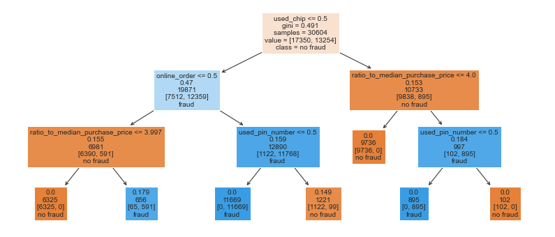

```python
fig = plt.figure(figsize=(14,6))
tree_plot = tree.plot_tree(clf,
                   feature_names=list(X_train.columns),
                   class_names=['no fraud', 'fraud'],
                   filled=True,
                   fontsize=10,
                   label='root')
```

## Calculate random forrest classifier

```python
X2_train, X2_test, y2_train, y2_test = train_test_split(df_filtered[[ 'distance_from_home',
                                                                'distance_from_last_transaction',
                                                                'ratio_to_median_purchase_price',
                                                                'repeat_retailer',
                                                                'used_chip',
                                                                'used_pin_number',
                                                                'online_order']],
                                                                df_filtered['fraud'],
                                                        test_size=0.20,
                                                        random_state=42)
# Show X2_train
print('X2_train:')
print(X2_train.head(), '\n')

# Show y2_train
print('y2_train:')
print(y2_train.head())
# Initialize the random forest classifier
rfc = RandomForestClassifier(random_state=20, max_depth=10)

# Train the random forest classifier
rfc = rfc.fit(X2_train, y2_train)

# Predict the target variable (0 = not survived, 1 = survived) -------------------------------------------------!!!!!!!!!
y_pred_rf = rfc.predict(X2_test)
y_pred_rf
```

```
X2_train:
        distance_from_home  distance_from_last_transaction  \
526522          160.757690                        1.718735
677611          129.567583                        3.299068
15448           343.009460                        2.414495
429232          197.273291                        0.356006
555804          114.532922                        0.122935

        ratio_to_median_purchase_price  repeat_retailer  used_chip  \
526522                        0.227596              1.0        0.0
677611                        1.931845              1.0        0.0
15448                         0.891566              1.0        0.0
429232                        0.732512              1.0        0.0
555804                        1.087891              1.0        0.0

        used_pin_number  online_order
526522              0.0           1.0
677611              0.0           1.0
15448               0.0           0.0
429232              0.0           1.0
555804              0.0           1.0

y2_train:
526522    1.0
677611    1.0
15448     0.0
429232    1.0
555804    1.0
Name: fraud, dtype: float64
```

```
array([1., 1., 0., ..., 1., 0., 1.])
```

```python
# The following function was provided by Maria Pelli

def make_confusion_matrix(cf_matrix, group_names=None, categories='auto', count=True,
                          percent=True, cbar=True, xyticks=True, xyplotlabels=True,
                          figsize=None, cmap='Blues'):
    """
    This function prints and plots a confusion matrix.
    """
    group_counts = ["{0:0.0f}".format(value) for value in cf_matrix.flatten()]
    group_percentages = ["{0:.2%}".format(value) for value in cf_matrix.flatten() / np.sum(cf_matrix)]

    labels = [f"{v1}\n{v2}\n{v3}" for v1, v2, v3 in zip(group_names, group_counts, group_percentages)]
    labels = np.asarray(labels).reshape(cf_matrix.shape[0], cf_matrix.shape[1])

    sns.heatmap(cf_matrix, annot=labels, fmt='', cmap=cmap, cbar=cbar, xticklabels=categories,
                yticklabels=categories)

    if xyticks:
        plt.xticks(ticks=np.arange(cf_matrix.shape[1]) + 0.5, labels=categories)
        plt.yticks(ticks=np.arange(cf_matrix.shape[0]) + 0.5, labels=categories)

    if xyplotlabels:
        plt.xlabel('Predicted')
        plt.ylabel('Actual')

    plt.title('Confusion Matrix')
    if figsize is not None:
        plt.figure(figsize=figsize)
    plt.show()
```

```python
print(y_test)
X_test
```

```
995421    1.0
109127    1.0
296684    0.0
117822    1.0
519957    0.0
         ...
928423    1.0
980671    0.0
573056    1.0
228450    0.0
85366     1.0
Name: fraud, Length: 7651, dtype: float64
```

|  | distance_from_home | distance_from_last_transaction | ratio_to_median_purchase_price | repeat_retailer | used_chip | used_pin_number | online_order |
| --- | --- | --- | --- | --- | --- | --- | --- |
| 995421 | 291.504507 | 0.042312 | 0.534283 | 1.0 | 0.0 | 0.0 | 1.0 |
| 109127 | 708.485616 | 2.344455 | 0.538750 | 1.0 | 0.0 | 0.0 | 1.0 |
| 296684 | 128.390346 | 0.324912 | 1.471690 | 1.0 | 0.0 | 0.0 | 0.0 |
| 117822 | 113.383195 | 1.211976 | 0.333105 | 1.0 | 0.0 | 0.0 | 1.0 |
| 519957 | 158.427706 | 2.574598 | 1.322991 | 1.0 | 0.0 | 0.0 | 0.0 |
| ... | ... | ... | ... | ... | ... | ... | ... |
| 928423 | 140.902582 | 0.908270 | 3.406002 | 1.0 | 0.0 | 0.0 | 1.0 |
| 980671 | 117.897036 | 0.523283 | 1.422071 | 1.0 | 0.0 | 0.0 | 0.0 |
| 573056 | 105.842008 | 0.065900 | 4.971408 | 1.0 | 1.0 | 0.0 | 0.0 |
| 228450 | 159.769840 | 1.071501 | 0.611716 | 1.0 | 1.0 | 0.0 | 1.0 |
| 85366 | 115.377623 | 1.661706 | 6.970760 | 1.0 | 0.0 | 0.0 | 0.0 |

7651 rows × 7 columns

#### Classification report

```python
print(classification_report(y_test, y_pred))
```

```
              precision    recall  f1-score   support

         0.0       0.99      1.00      0.99      4274
         1.0       0.99      0.99      0.99      3377

    accuracy                           0.99      7651
   macro avg       0.99      0.99      0.99      7651
weighted avg       0.99      0.99      0.99      7651
```

#### Confusion matrix

```python
print(confusion_matrix(y_test, y_pred), '\n')
```

```
[[4257   17]
 [  29 3348]]
```

```
[[4257   17]
 [  29 3348]]
```

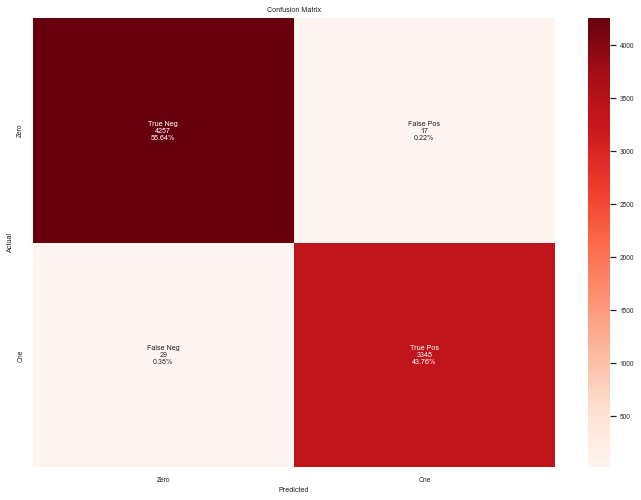

```python
#Get the confusion matrix
cf_matrix = confusion_matrix(y_test, y_pred)
print(cf_matrix)

labels = ['True Neg','False Pos','False Neg','True Pos']
categories = ['Zero', 'One']
make_confusion_matrix(cf_matrix, group_names=labels, categories=categories, figsize=(3,2), cmap='Reds')
```

#### Plot feature importance

```
Index(['online_order', 'used_chip', 'ratio_to_median_purchase_price',
       'used_pin_number', 'distance_from_last_transaction',
       'distance_from_home', 'repeat_retailer'],
      dtype='object')
[0.37173482 0.36183318 0.15120901 0.11041927 0.00248624 0.00231747
 0.        ]
```

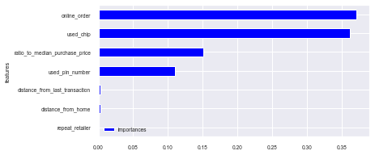

```python
cols = X2_train.columns
importances = rfc.feature_importances_
std = np.std([tree.feature_importances_ for tree in rfc.estimators_], axis=0)
indices = np.argsort(importances)[::-1]
print( cols[indices] )
print( importances[indices] )
df_fi = pd.DataFrame({'features':cols,'importances': importances})
df_fi.sort_values('importances', inplace=True)
df_fi.plot(kind='barh',
           y='importances',
           x='features',
           color='blue',
           figsize=(6,3))
```

#### Plot ROC curve and calculate AUC

```python
from sklearn.metrics import RocCurveDisplay
plt.figure(figsize=(6,4))
rfc_disp = RocCurveDisplay.from_estimator(rfc,
                                          X_test,
                                          y_test,
                                          alpha=0.8,
                                          c="darkblue")
plt.show()
```

[output not shown]

## Logistic Regression

Der folgende code basiert auf dem, im Modul "Python Grundlagen und Anwendung in DataScience" von Frau Maria Pelli zur Verfügung gestellten, Code.

```python
import sklearn
import time
from sklearn.model_selection import cross_val_score
from sklearn.linear_model import LogisticRegression
from sklearn.metrics import confusion_matrix, classification_report, log_loss, f1_score
import shap
```

```python
# Split the dataframe into features (X) and target variable (y)
X = df_filtered[['distance_from_home', 'distance_from_last_transaction', 'ratio_to_median_purchase_price',
        'repeat_retailer', 'used_chip', 'used_pin_number', 'online_order']]
y = df_filtered['fraud']
```

```python
# Create the logistic regression model
lr_a = LogisticRegression(max_iter=1000, solver='liblinear')
```

```python
# Perform train-test split
X2_train, X2_test, y2_train, y2_test = train_test_split(X, y, test_size=0.2, random_state=42)

# Perform cross-validation
scores = cross_val_score(lr_a, X2_train, y2_train, cv=5)  # Specify the number of folds for cross-validation

# Print the cross-validation scores
print("Cross-validation scores:", scores)
print("Mean cross-validation score:", scores.mean())
```

[output not shown]

```python
# Fit the logistic regression model on the training data
lr_a.fit(X2_train, y2_train)

# Predict on the test data
y2_pred = lr_a.predict(X2_test)

# Print evaluation metric "Classification Report" on the test data
print("Classification Report:")
print(classification_report(y2_test, y2_pred))
```

[output not shown]

```python
# Calculate accuracy score on train and test data
train_score = lr_a.score(X2_train, y2_train)
test_score = lr_a.score(X_test, y_test)
print("Accuracy score on train data: ", train_score)
print("Accuracy score on test data: ", test_score)

# Calculate log loss on train and test data
train_log_loss = log_loss(y2_train, lr_a.predict_proba(X2_train))
test_log_loss = log_loss(y_test, lr_a.predict_proba(X_test))
print("Log Loss on train data: ", train_log_loss)
print("Log Loss on test data: ", test_log_loss)

# Calculate F1 score on train and test data
train_f1_score = f1_score(y2_train, lr_a.predict(X2_train))
test_f1_score = f1_score(y_test, lr_a.predict(X_test))
print("F1 score on train data: ", train_f1_score)
print("F1 score on test data: ", test_f1_score)
```

[output not shown]

```python
#Get the confusion matrix
cf_matrix = confusion_matrix(y2_test, y2_pred)
print(cf_matrix)

labels = ['True Neg','False Pos','False Neg','True Pos']
categories = ['Zero', 'One']
make_confusion_matrix(cf_matrix, group_names=labels, categories=categories, figsize=(7,4), cmap='Reds')
```

[output not shown]

```python
# The following function was provided by Maria Pelli
def print_accuracy(f):
    print("Accuracy = {0}%".format(100*np.sum(f(X_test) == y2_test)/len(y2_test)))
    time.sleep(0.5) # to let the print get out before any progress bars

shap.initjs()
```

## Downsampling rows of fraud=negative to 60% (-> and fraud=positive: 40%) and train new model to reevaluate model

```python
from sklearn.utils import resample

# Separate majority and minority classes
df_majority = df_filtered[df_filtered['fraud'] == 0.0]
df_minority = df_filtered[df_filtered['fraud'] == 1.0]

# Determine the desired number of rows for the minority class
desired_rows_minority = int(0.4 * len(df_majority) / 0.6)

# Undersample the majority class to match the desired class balance
df_majority_downsampled = resample(df_majority,
                                   replace=False,  # Set to False for undersampling
                                   n_samples=desired_rows_minority,
                                   random_state=42)

# Concatenate the downsampled majority class and the original minority class
df_downsampled = pd.concat([df_majority_downsampled, df_minority])

# Shuffle the DataFrame to randomize the order of rows
df_downsampled = df_downsampled.sample(frac=1, random_state=42)

# Verify the class balance in the downsampled DataFrame
print(df_downsampled['fraud'].value_counts())

# Use the downsampled DataFrame for further analysis or modeling
X3 = df_downsampled.drop('fraud', axis=1)
y3 = df_downsampled['fraud']
```

[output not shown]

```python
# Create the logistic regression model
lr_a = LogisticRegression(max_iter=1000, solver='liblinear')

# Perform train-test split
X3_train, X3_test, y3_train, y3_test = train_test_split(X3, y3, test_size=0.2, random_state=42)

# Perform cross-validation
scores = cross_val_score(lr_a, X3_train, y3_train, cv=5)  # Specify the number of folds for cross-validation

# Print the cross-validation scores
print("Cross-validation scores:", scores)
print("Mean cross-validation score:", scores.mean())

# Fit the logistic regression model on the training data
lr_a.fit(X3_train, y3_train)

# Predict on the test data
y3_pred = lr_a.predict(X3_test)

# Print evaluation metrics on the test data
print("Classification Report:")
print(classification_report(y3_test, y3_pred))

# Calculate accuracy score on train and test data
train_score = lr_a.score(X3_train, y3_train)
test_score = lr_a.score(X3_test, y3_test)
print("Accuracy score on train data: ", train_score)
print("Accuracy score on test data: ", test_score)

# Calculate log loss on train and test data
train_log_loss = log_loss(y3_train, lr_a.predict_proba(X3_train))
test_log_loss = log_loss(y3_test, lr_a.predict_proba(X3_test))
print("Log Loss on train data: ", train_log_loss)
print("Log Loss on test data: ", test_log_loss)

# Calculate F1 score on train and test data
train_f1_score = f1_score(y3_train, lr_a.predict(X3_train))
test_f1_score = f1_score(y3_test, lr_a.predict(X3_test))
print("F1 score on train data: ", train_f1_score)
print("F1 score on test data: ", test_f1_score)
```

[output not shown]

```python
#Get the confusion matrix
cf_matrix = confusion_matrix(y3_test, y3_pred)
print(cf_matrix)

labels = ['True Neg','False Pos','False Neg','True Pos']
categories = ['Zero', 'One']
make_confusion_matrix(cf_matrix, group_names=labels, categories=categories, figsize=(7,4), cmap='Reds')
```

[output not shown]

### Anwendung von XAI – Techniken

- Anwendung von XAI – Techniken, um die entwickelten Modelle in Bezug auf die Fallstudie zu erklären

```python
import shap

# explain all the predictions in the test set
explainer = shap.TreeExplainer(rfc)
shap_values = explainer.shap_values(X_test)
shap.summary_plot(shap_values, X_test)
```

[output not shown]

```python
shap.dependence_plot("online_order", shap_values[0], X_test)
```

[output not shown]

```python
shap.dependence_plot("distance_from_home", shap_values[0], X_test)
```

[output not shown]

```python
shap.dependence_plot("ratio_to_median_purchase_price", shap_values[0], X_test)
```

[output not shown]

##### Jupyter notebook --footer info--

```python
import os
import platform
import socket
from platform import python_version
from datetime import datetime

print('-----------------------------------')
print(os.name.upper())
print(platform.system(), '|', platform.release())
print('Datetime:', datetime.now().strftime("%Y-%m-%d %H:%M:%S"))
print('Python Version:', python_version())
print('-----------------------------------')
```